# HW 4

due 4/6/23

Author

Ava Waters

Published

April 6, 2023

**Please remember that this homework is to be done individually!**

**Look at `hw4_instructions.html` for more information on the two data sets and for helpful hints throughout.**

## Packages

```r
library(tidyverse)
library(reticulate)
```

```python
import pandas as pd
import numpy as np
import seaborn as sns
import matplotlib.pyplot as plt
from sklearn.model_selection import train_test_split, GridSearchCV, StratifiedShuffleSplit
from sklearn.compose import make_column_transformer
from sklearn.preprocessing import StandardScaler, OneHotEncoder
from sklearn.pipeline import Pipeline
from sklearn.kernel_approximation import Nystroem
from sklearn.linear_model import SGDClassifier
from sklearn.metrics import roc_auc_score
from sklearn.ensemble import GradientBoostingClassifier
```

# Exercises

```r
# load data
load("data/vendor_data.RData")

# changing vars to factors
vendor_data$market <- as.factor(vendor_data$market)
vendor_data$district <- as.factor(vendor_data$district)
```

## Q1: Data Visualization

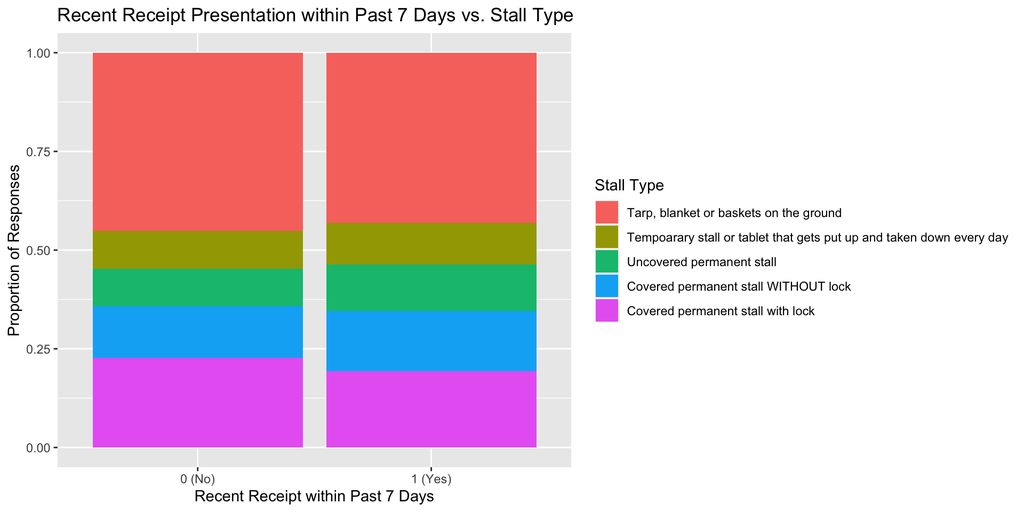

```r
vendor_data %>% drop_na(recent_receipt_7) %>% # drop NA values
  drop_na(stall_type) %>% # drop NA values
  ggplot(aes(x=as.factor(recent_receipt_7), fill=stall_type)) + geom_bar(position="fill") +
  labs(title="Recent Receipt Presentation within Past 7 Days vs. Stall Type", # add titles
       x="Recent Receipt within Past 7 Days", y="Proportion of Responses", fill="Stall Type") +
  scale_x_discrete(labels=c("0 (No)", "1 (Yes)")) # change x axis tick labels
```

This visualization plots the proportion of respondents with each type of stall against whether or not they have shown a receipt within the past 7 days. Since each chunk is relatively similar in size, it doesn’t seem like there is a big difference between stall types and the `recent_receipt_7` response. I thought maybe vendors who have more permanent or solid stall types would be more established, which may affect their response (but not sure in which direction). Interestingly, a larger proportion vendors who haven’t shown a receipt recently have both the most established and un-established types of stalls.

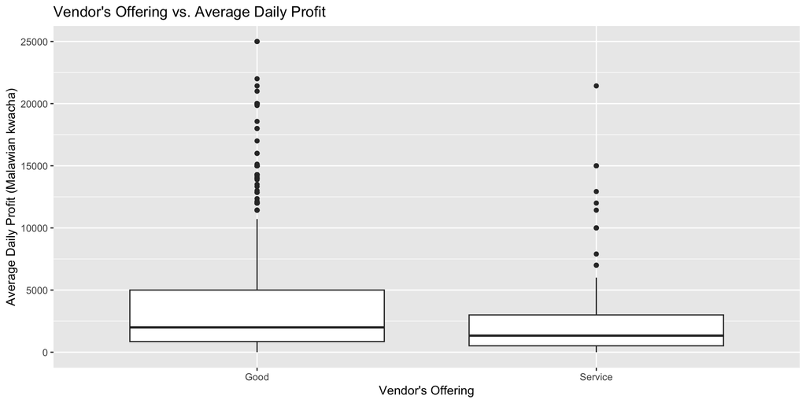

```r
# zoomed in view
vendor_data %>% drop_na(service) %>% drop_na(profit) %>% # drop NA values
  ggplot(aes(x=as.factor(service), y=profit)) + geom_boxplot() +
  ylim(0, 25000) + # zoom in for better look at boxes
  labs(title="Vendor's Offering vs. Average Daily Profit", x="Vendor's Offering",
       y="Average Daily Profit (Malawian kwacha)") +
  scale_x_discrete(labels=c("Good", "Service"))
```

## Q2: Train-Test Split

```python
# drop NA values
vendor_data = r.vendor_data.dropna()

X = vendor_data.drop(["recent_receipt_7", "unequal_test", "market"], axis = 1)

y = np.ravel(vendor_data["recent_receipt_7"])

X_train, X_test, y_train, y_test = train_test_split(X, y, random_state = 20)
```

1. We have to drop all `NA`s (and missing values) because having missing data may mess up the model training. If a lot of data is missing from the training set, it would be hard to build a model with incomplete information. Or, the patterns may not be accurate because it does not represent the data. If a lot of data is missing from the test set, the output may not be representative of the model’s performance because it has less information than it usually would. This could be a problem if a lot of data is missing, leading to a small amount of remaining observations. Then, the splits would be small and probably less accurate. Also, there may be a systematic reason why some data is missing for some observations. Thinking about why that is, and perhaps investigating, may be more helpful than just ignoring these cases.
2. The trade-off between test set size and training set size relates to the model’s performance. If the test set is too small, we may not be able to get an accurate sense of how the model performs on unseen data. The model’s performance would be very dependent on what observations fall into this test set. If the training set is too small, it may not accurately represent the data and may lead to a model that doesn’t fit all of the data well. This may lead to high variance and error scores when predicting on the test set.

## Q3: Support Vector Machine

```python
# columns not included are binary cols that we are passing thru
# categorical cols (by index)
cat_cols = X.iloc[:, [0, 1, 4, 6, 8, 9, 21, 24]].columns
# numerical cols (by index)
num_cols = X.iloc[:, [3, 7, 10, 11, 12, 13, 14, 15, 16, 17, 19, 20, 22, 23]].columns

preprocessor = make_column_transformer((OneHotEncoder(drop = "first"),
                                                      cat_cols),
                                      (StandardScaler(), num_cols),
                                      remainder = "passthrough",
                                      verbose_feature_names_out = False)

# defining the grid of params
alpha = np.logspace(-4, 4, 10)
gamma = np.logspace(-4, 4, 10)
kernel = ["rbf", "linear"]

param_grid_svm = dict(
  kernel_approx__gamma = gamma,
  kernel_approx__kernel = kernel,
  estimator__alpha = alpha
)

pipeline_svm = Pipeline(
  [
    ("preprocess", preprocessor),
    ("kernel_approx", Nystroem(random_state = 101)),
    ("estimator", SGDClassifier(random_state = 102))
  ]
)

cv = StratifiedShuffleSplit(n_splits = 5, random_state = 100)

# perform grid search for SVM pipeline
grid_svm = (
  GridSearchCV(pipeline_svm, param_grid = param_grid_svm,
               scoring = "roc_auc", cv = cv)
  .fit(X_train, y_train)
)

# fit pipeline with optimal tuning params
pipeline_svm_optimal = grid_svm.best_estimator_
pipeline_svm_optimal.fit(X_train, y_train)

# get AUC from test set
```

```
Pipeline(steps=[('preprocess',
                 ColumnTransformer(remainder='passthrough',
                                   transformers=[('onehotencoder',
                                                  OneHotEncoder(drop='first'),
                                                  Index(['district', 'language', 'tribe', 'education', 'literacy',
       'reading_language', 'profit_lst_yr_month', 'stall_type'],
      dtype='object')),
                                                 ('standardscaler',
                                                  StandardScaler(),
                                                  Index(['age', 'educ_num', 'houses', 'acres_farmland', 'bicycles', 'chickens',
       'goats', 'basic_cell_phones', 'smart_phones', 'days_pr_week',
       'yrs_in_mkt_fix', 'profit', 'hh_income_trim_99',
       'customers_pr_day_trim_99'],
      dtype='object'))],
                                   verbose_feature_names_out=False)),
                ('kernel_approx',
                 Nystroem(gamma=0.005994842503189409, random_state=101)),
                ('estimator', SGDClassifier(random_state=102))])
```

```python
auc_svm = roc_auc_score(y_test, pipeline_svm_optimal.predict(X_test))

# reset index so i can split according to rows in X_test
X_test.reset_index(drop = True, inplace = True)
# split test sets on marriage col
X_test_married = X_test[X_test["married"] == 1]
y_test_married = y_test[X_test_married.index]
X_test_unmarried = X_test[X_test["married"] == 0]
y_test_unmarried = y_test[X_test_unmarried.index]

# compute AUC scores
auc_married = roc_auc_score(y_test_married, pipeline_svm_optimal.predict(X_test_married))
auc_unmarried = roc_auc_score(y_test_unmarried, pipeline_svm_optimal.predict(X_test_unmarried))
```

We can use ROC curve AUC for SVMs because we can plot the sensitivity and specificity of the model. While ROC curves are usually for probabilities, and SVMs only return the classification (no probability), we can still calculate the true and false positive and negative rates because we have the predicted and true Y values. Then, the ROC curve plots sensitivity (true positive rate) vs. 1 - specificity (false positive rate). Each point represents these values at different threshold values $c$, and the AUC then can be computed from the curve these points form.

The optimal tuning parameters are:

alpha = 10^{-4}

gamma = 0.0059948

kernel = rbf

The AUC on the overall test set is 0.6028505

The AUC for the subsample of the test set who are married is different from that for the subsample who aren’t married. The AUC for married vendors is 0.6088816, whereas the AUC for unmarried vendors is 0.5785714. This could mean that marriage (or the legality of it) affects their behavior in some systematic way and whether they have shown a receipt becomes more predictable (since the model performs better). Or, marriage could be an indicator of another underlying variable that affects both `recent_receipt_7` and marriage status.

## Q4: Gradient Boosting Machine

```python
# defining the grid of params
b = np.arange(5000, 8000, 1000) # aka num of trees
lamb =[0.001, 0.01] # aka learning rate
d = np.arange(1, 3) # aka num of splits (dept of tree)

param_grid_gbm = dict(
  gbm__n_estimators = b,
  gbm__learning_rate = lamb,
  gbm__max_depth = d
)

pipeline_gbm = Pipeline(
  [
    ("preprocess", preprocessor),
    ("gbm", GradientBoostingClassifier(random_state = 0,
                                       subsample = 0.5))
  ]
)

# perform grid search for SVM pipeline
grid_gbm = (
  GridSearchCV(pipeline_gbm, param_grid = param_grid_gbm,
               scoring = "roc_auc", cv = cv)
  .fit(X_train, y_train)
)

# fit pipeline with optimal tuning params
pipeline_gbm_optimal = grid_gbm.best_estimator_
pipeline_gbm_optimal.fit(X_train, y_train)

# get AUC from test set
```

```
Pipeline(steps=[('preprocess',
                 ColumnTransformer(remainder='passthrough',
                                   transformers=[('onehotencoder',
                                                  OneHotEncoder(drop='first'),
                                                  Index(['district', 'language', 'tribe', 'education', 'literacy',
       'reading_language', 'profit_lst_yr_month', 'stall_type'],
      dtype='object')),
                                                 ('standardscaler',
                                                  StandardScaler(),
                                                  Index(['age', 'educ_num', 'houses', 'acres_farmland', 'bicycles', 'chickens',
       'goats', 'basic_cell_phones', 'smart_phones', 'days_pr_week',
       'yrs_in_mkt_fix', 'profit', 'hh_income_trim_99',
       'customers_pr_day_trim_99'],
      dtype='object'))],
                                   verbose_feature_names_out=False)),
                ('gbm',
                 GradientBoostingClassifier(learning_rate=0.001, max_depth=2,
                                            n_estimators=5000, random_state=0,
                                            subsample=0.5))])
```

```python
auc_gbm = roc_auc_score(y_test, pipeline_gbm_optimal.predict(X_test))
```

The optimal tuning parameters are:

B = 5000

$\lambda$ = 0.001

d = 2

The AUC on the overall test set is 0.5379317.

This model performs worse compared to the SVM. Because the AUC is about 0.06 lower than that of the SVM model, it does a bit worse at predicting on unseen data.

## Q5: With Not Randomly Selected Training Data

```python
# split train and test sets based on unequal_test col
X_train_new = vendor_data[vendor_data["unequal_test"] == 0].drop(["recent_receipt_7", "market"], axis = 1)
y_train_new = vendor_data[vendor_data["unequal_test"] == 0].loc[:, "recent_receipt_7"]
X_test_new = vendor_data[vendor_data["unequal_test"] == 1].drop(["recent_receipt_7", "market"], axis = 1)
y_test_new = vendor_data[vendor_data["unequal_test"] == 1].loc[:, "recent_receipt_7"]

# look at language, district, and stall type variables based on proportion of occurrence in each data set
X_train_new["language"].value_counts(normalize = True)
```

```
Chichewa    0.947661
Tumbuka     0.052339
English     0.000000
Yawo        0.000000
Name: language, dtype: float64
```

```python
X_test_new["language"].value_counts(normalize = True)
```

```
Chichewa    0.991477
Tumbuka     0.008523
English     0.000000
Yawo        0.000000
Name: language, dtype: float64
```

```python
X_train_new["district"].value_counts(normalize = True)
```

```
3    0.268041
5    0.257732
4    0.187946
8    0.159397
6    0.082474
7    0.028549
1    0.011102
2    0.004758
Name: district, dtype: float64
```

```python
X_test_new["district"].value_counts(normalize = True)
```

```
7    0.407670
1    0.224432
2    0.167614
3    0.058239
5    0.051136
4    0.042614
8    0.028409
6    0.019886
Name: district, dtype: float64
```

```python
X_train_new["stall_type"].value_counts(normalize = True)
```

```
Tarp, blanket or baskets on the ground                                  0.447264
Covered permanent stall with lock                                       0.222839
Covered permanent stall WITHOUT lock                                    0.139572
Uncovered permanent stall                                               0.107058
Tempoarary stall or tablet that gets put up and taken down every day    0.083267
Name: stall_type, dtype: float64
```

```python
X_test_new["stall_type"].value_counts(normalize = True)

# SVM had the better performance, so re-fit the model to the new training data
```

```
Tarp, blanket or baskets on the ground                                  0.446023
Covered permanent stall with lock                                       0.177557
Covered permanent stall WITHOUT lock                                    0.137784
Tempoarary stall or tablet that gets put up and taken down every day    0.130682
Uncovered permanent stall                                               0.107955
Name: stall_type, dtype: float64
```

```python
pipeline_svm.fit(X_train_new, y_train_new)
```

```
Pipeline(steps=[('preprocess',
                 ColumnTransformer(remainder='passthrough',
                                   transformers=[('onehotencoder',
                                                  OneHotEncoder(drop='first'),
                                                  Index(['district', 'language', 'tribe', 'education', 'literacy',
       'reading_language', 'profit_lst_yr_month', 'stall_type'],
      dtype='object')),
                                                 ('standardscaler',
                                                  StandardScaler(),
                                                  Index(['age', 'educ_num', 'houses', 'acres_farmland', 'bicycles', 'chickens',
       'goats', 'basic_cell_phones', 'smart_phones', 'days_pr_week',
       'yrs_in_mkt_fix', 'profit', 'hh_income_trim_99',
       'customers_pr_day_trim_99'],
      dtype='object'))],
                                   verbose_feature_names_out=False)),
                ('kernel_approx', Nystroem(random_state=101)),
                ('estimator', SGDClassifier(random_state=102))])
```

```python
auc = roc_auc_score(y_test_new, pipeline_svm.predict(X_test_new))
```

The AUC on the data the model hasn’t seen yet is 0.5162017.

This seems worse than the overall test AUC when we randomly split our data. This may be because of the unbalanced split of some of the predictors (like `district`). This implies that these unbalanced variables may be important. If the distribution of them is associated with how well the model performs, then it may have an effect on predicting the outcome variable.

## Q6: Introspection

A large downsize of this tool is the potential criminalization of vendors who don’t pay the market tax. As you mentioned in the Data section, noncompliance to paying this flat tax often is correlated to poor market conditions. That probably implies that these vendors are struggling already. It would be unproductive to further punish them. In my opinion, predictions of this kind are not a good idea. The resources used to building these models should be instead used to support the market and the vendors.